# Model Selection & Regularization

Author

Daniel Redel

# ISLR: Baseball Players Salary

Here we apply regularization methods to the `Hitters` data. We wish to predict a baseball player’s `Salary` on the basis of various statistics associated with performance in the previous year.

First, let’s clean the missing values.

```r
library(dplyr)
hitters <- ISLR::Hitters %>% na.omit()
```

Table 1: Baseball Dataset

|  | AtBat | Hits | HmRun | Runs | RBI | Walks | Years | CAtBat | CHits | CHmRun | CRuns | CRBI | CWalks | League | Division | PutOuts | Assists | Errors | Salary | NewLeague |
| --- | --- | --- | --- | --- | --- | --- | --- | --- | --- | --- | --- | --- | --- | --- | --- | --- | --- | --- | --- | --- |
| -Alan Ashby | 315 | 81 | 7 | 24 | 38 | 39 | 14 | 3449 | 835 | 69 | 321 | 414 | 375 | N | W | 632 | 43 | 10 | 475.0 | N |
| -Alvin Davis | 479 | 130 | 18 | 66 | 72 | 76 | 3 | 1624 | 457 | 63 | 224 | 266 | 263 | A | W | 880 | 82 | 14 | 480.0 | A |
| -Andre Dawson | 496 | 141 | 20 | 65 | 78 | 37 | 11 | 5628 | 1575 | 225 | 828 | 838 | 354 | N | E | 200 | 11 | 3 | 500.0 | N |
| -Andres Galarraga | 321 | 87 | 10 | 39 | 42 | 30 | 2 | 396 | 101 | 12 | 48 | 46 | 33 | N | E | 805 | 40 | 4 | 91.5 | N |
| -Alfredo Griffin | 594 | 169 | 4 | 74 | 51 | 35 | 11 | 4408 | 1133 | 19 | 501 | 336 | 194 | A | W | 282 | 421 | 25 | 750.0 | A |
| -Al Newman | 185 | 37 | 1 | 23 | 8 | 21 | 2 | 214 | 42 | 1 | 30 | 9 | 24 | N | E | 76 | 127 | 7 | 70.0 | A |

## Summary Statistics

We can show some statistics

```r
hitters %>%
  dplyr::select(Salary, Years, Hits, CHits, HmRun, Runs, AtBat, CAtBat, Walks) %>%
  tbl_summary(statistic = list(
    all_continuous() ~ "{mean} ({sd})"),
    digits = all_continuous() ~ 3)
```

Table 2: Summary Statistics

| **Characteristic** | **N = 263**<sup>1</sup> |
| --- | --- |
| Salary | 535.926 (451.119) |
| Years | 7.312 (4.794) |
| Hits | 107.829 (45.125) |
| CHits | 722.186 (648.200) |
| HmRun | 11.620 (8.757) |
| Runs | 54.745 (25.540) |
| AtBat | 403.643 (147.307) |
| CAtBat | 2,657.544 (2,286.583) |
| Walks | 41.114 (21.718) |

<sup>1</sup> Mean (SD)

Let’s take a closer look at the `Salary` distribution:

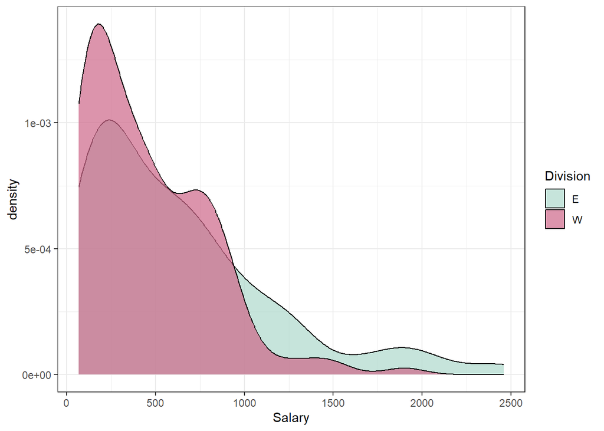

Figure 1: Salary Distribution of Baseball Players

```r
hitters %>%
  ggplot(aes(x = Salary, fill = Division)) +
  geom_density(alpha = 0.7) +
  scale_fill_manual(values = mycolors) + theme_bw()
```

## Ridge Regression

We will use the `glmnet` package to perform ridge regression. The main function in this package is `glmnet()`, which can be used to fit ridge regression models, lasso models, and more.

This function has slightly different syntax from other model-fitting functions that we have encountered thus far. In particular, we must pass in an `x` matrix as well as a `y` vector, and we do not use the `y ∼ x` syntax.

```r
x <- model.matrix(Salary~., data = hitters)[,-1]
y <- hitters$Salary
```

The `glmnet()` function has an `alpha` argument that determines what type of model is fit. If `alpha=0` then a **ridge regression** model is fit, and if `alpha=1` then a lasso model is fit. We first fit a ridge regression model.

- We choose to compute the ridge regression using a range of lambda values that goes from `10^10` (very close to the null model, including only the intercept) to `10^(-2)` (very close to the full OLS model).
- Note that by default, the `glmnet()` function standardizes the variables so that they are on the same scale. To turn off this default setting, use the argument `standardize = FALSE`.

```r
grid <- 10^seq(10, -2, length = 100)
ridge.mod <- glmnet(x, y, alpha = 0, lambda = grid)
```

Ridge gives us a **path** of possible models:

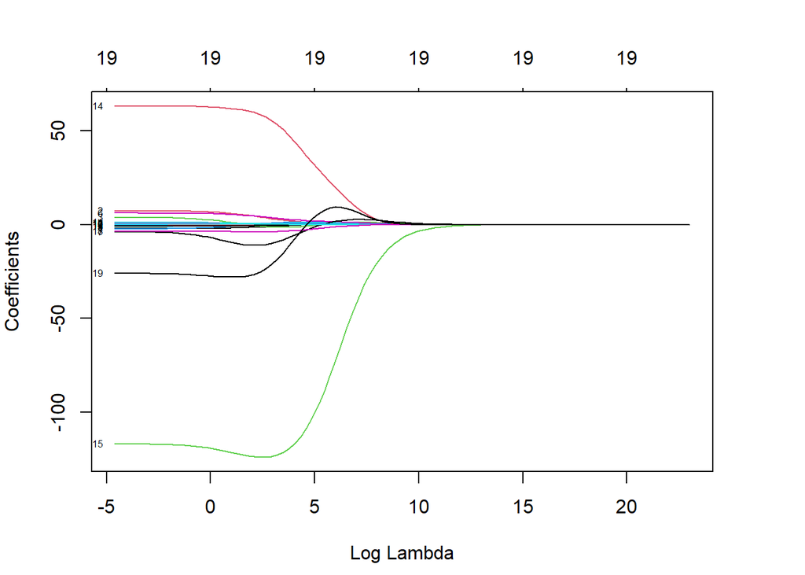

```r
par(mai=c(.9,.8,.8,.8))
par(mfrow=c(1,1))
plot(ridge.mod, xvar="lambda", label = TRUE, )
```

Let’s quickyl check how the coefficients changes at different values for $\lambda$:

First with $\lambda=11,498$:

```r
ridge.mod[["lambda"]][50]
```

```
[1] 11497.57
```

```r
coefficients <- coef(ridge.mod, )[, 50]

as.data.frame(coefficients) %>%
  kbl() %>%
  kable_styling(bootstrap_options = c("striped", "hover", "condensed"))
```

Table 3: Ridge Coefficients (Lambda=11,498)

|  | coefficients |
| --- | --- |
| (Intercept) | 407.3560502 |
| AtBat | 0.0369572 |
| Hits | 0.1381803 |
| HmRun | 0.5246300 |
| Runs | 0.2307015 |
| RBI | 0.2398415 |
| Walks | 0.2896187 |
| Years | 1.1077029 |
| CAtBat | 0.0031318 |
| CHits | 0.0116536 |
| CHmRun | 0.0875457 |
| CRuns | 0.0233799 |
| CRBI | 0.0241383 |
| CWalks | 0.0250154 |
| LeagueN | 0.0850281 |
| DivisionW | -6.2154410 |
| PutOuts | 0.0164826 |
| Assists | 0.0026130 |
| Errors | -0.0205027 |
| NewLeagueN | 0.3014335 |

```r
ridge.mod[["lambda"]][60]
```

```
[1] 705.4802
```

```r
coefficients <- coef(ridge.mod, )[, 60]

as.data.frame(coefficients) %>%
  kbl() %>%
  kable_styling(bootstrap_options = c("striped", "hover", "condensed"))
```

Table 4: Ridge Coefficients (Lambda=705)

|  | coefficients |
| --- | --- |
| (Intercept) | 54.3251995 |
| AtBat | 0.1121111 |
| Hits | 0.6562241 |
| HmRun | 1.1798091 |
| Runs | 0.9376971 |
| RBI | 0.8471855 |
| Walks | 1.3198795 |
| Years | 2.5964042 |
| CAtBat | 0.0108341 |
| CHits | 0.0467456 |
| CHmRun | 0.3377732 |
| CRuns | 0.0935553 |
| CRBI | 0.0978040 |
| CWalks | 0.0718961 |
| LeagueN | 13.6837019 |
| DivisionW | -54.6587775 |
| PutOuts | 0.1185229 |
| Assists | 0.0160604 |
| Errors | -0.7035865 |
| NewLeagueN | 8.6118121 |

**Main Idea**: The coefficients tend to be larger with a lower value of $\lambda$ (although some of them can increase their value).

### Validation Approach (Train and Test Data)

We now split the samples into a training set (70%) and a test set (30%) in order to estimate the test error of ridge regression and the lasso.

```r
set.seed(123456)
index <- sample(1:nrow(hitters), 0.7*nrow(hitters))

train_hitters <- hitters[index,] # Create the training data
test_hitters <- hitters[-index,] # Create the test data

dim(train_hitters)
```

```
[1] 184  20
```

```r
dim(test_hitters)
```

```
[1] 79 20
```

We convert it into a matrix:

```r
# Train
x_train <- model.matrix(Salary~., data = train_hitters)[,-1]
y_train <- train_hitters$Salary

# Test
x_test <- model.matrix(Salary~., data = test_hitters)[,-1]
y_test <- test_hitters$Salary
```

Now, to evaluate it’s predicting performance, we will use the **MSE/RMSE metrics**:

```r
eval_results <- function(true, predicted, df) {
  SSE <- sum((predicted - true)^2)
  MSE <- SSE/nrow(df)                            # Mean-Squared Error
  RMSE = sqrt(SSE/nrow(df))                      # Root Mean-Squared Error

  # Model performance metrics
data.frame(
  MSE = MSE,
  RMSE = RMSE
)

}
```

Let’s run the ridge regression in our training dataset and evaluate using $\lambda=4$:

```r
ridge.mod1 <- glmnet(x_train, y_train, alpha = 0, lambda = grid)

# Test Performance (MSE)
predict_ridge <- predict(ridge.mod1, s = 4, newx = x_test)
ridge_MSE <- eval_results(y_test, predict_ridge, test_hitters)
```

Table 5: Ridge Performance on Test

| MSE | RMSE |
| --- | --- |
| 123038.6 | 350.7686 |

What if we use a very large $\lambda$ ?

```r
ridge.mod2 <- glmnet(x_train, y_train, alpha = 0, lambda = grid)

# Test Performance (MSE)
predict_ridge <- predict(ridge.mod2, s = 1e10, newx = x_test)
ridge_MSE <- eval_results(y_test, predict_ridge, test_hitters)
```

Table 6: Ridge Performance on Test

| MSE | RMSE |
| --- | --- |
| 203250.7 | 450.8334 |

So fitting a ridge regression model with $λ = 4$ leads to a much lower test MSE than fitting a model with just an intercept.

### Choosing $\lambda$ with Cross-Validation

In general, instead of arbitrarily choosing $λ$, it would be better to use cross-validation to choose the tuning parameter $λ$. We can do this using the built-in cross-validation function, `cv.glmnet()`.

- By default, the function `cv.glmnet()` performs *ten-fold cross-validation*, though this can be changed using the argument `nfolds`. Let’s use 5 for our example
- Note that we set a **random seed first** so our results will be reproducible, since the choice of the cross-validation folds is random.

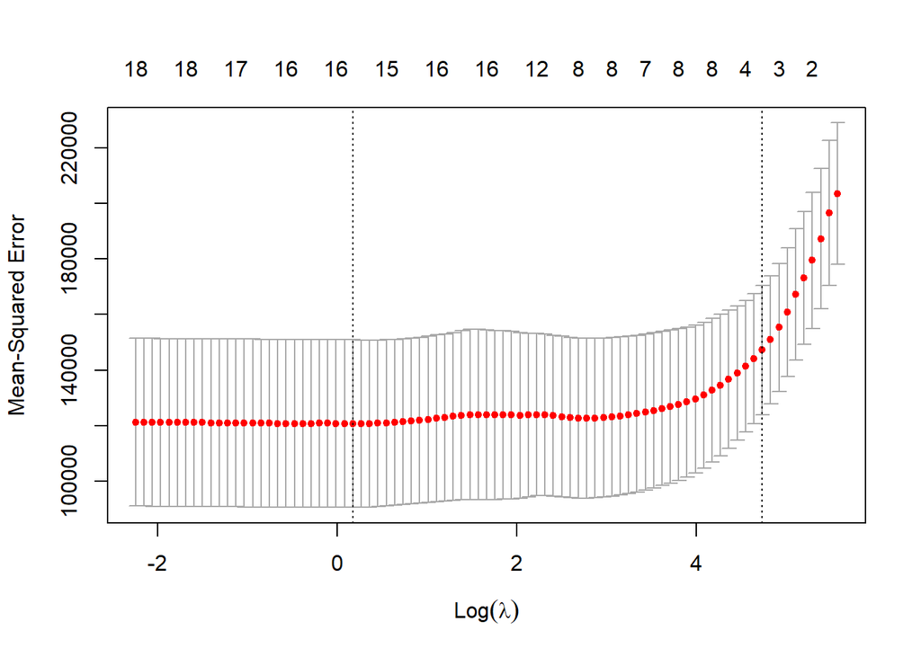

```r
set.seed(12345)
mod.ridge.cv <- cv.glmnet(x_train, y_train, type.measure = "mse", nfolds = 5)
plot(mod.ridge.cv)
```

As you can see from the plot, there are *two types of optimal* $\lambda$*’s* that we can use. We will consider both:

```r
# Save Optimal Lambdas
lambda_min.ridge <- mod.ridge.cv$lambda.min
print(lambda_min.ridge)
```

```
[1] 1.189541
```

```r
coeff_min <- coef(mod.ridge.cv, s = "lambda.min")[,1]

lambda_1se.ridge <- mod.ridge.cv$lambda.1se
print(lambda_1se.ridge)
```

```
[1] 113.5474
```

```r
coeff_1se <- coef(mod.ridge.cv, s = "lambda.1se")[,1]
```

```r
data.frame(cbind(coeff_min, coeff_1se)) %>%
  kbl() %>%
  kable_styling(bootstrap_options = c("striped", "hover", "condensed"))
```

|  | coeff_min | coeff_1se |
| --- | --- | --- |
| (Intercept) | 242.3167138 | 293.7115872 |
| AtBat | -2.3746030 | 0.0000000 |
| Hits | 7.0088455 | 0.0000000 |
| HmRun | -4.2660149 | 0.0000000 |
| Runs | -3.0257019 | 0.0000000 |
| RBI | 3.1703769 | 0.0000000 |
| Walks | 7.9740935 | 2.5880568 |
| Years | -20.3546933 | 0.0000000 |
| CAtBat | -0.0017199 | 0.0000000 |
| CHits | 0.0000000 | 0.0000000 |
| CHmRun | 1.5844970 | 0.0000000 |
| CRuns | 1.0091501 | 0.2339336 |
| CRBI | 0.0000000 | 0.2171932 |
| CWalks | -0.5131176 | 0.0000000 |
| LeagueN | 43.1992322 | 0.0000000 |
| DivisionW | -134.4769998 | 0.0000000 |
| PutOuts | 0.3003368 | 0.0000000 |
| Assists | 0.3766270 | 0.0000000 |
| Errors | -3.8907645 | 0.0000000 |
| NewLeagueN | 0.0000000 | 0.0000000 |

Now let’s use that value to predict `y_test` and check the MSE:

```r
ridge.mod3 <- glmnet(x_train, y_train, alpha = 0, lambda = lambda_min.ridge)
# Test Performance (MSE)
predict_ridge <- predict(ridge.mod3, newx = x_test)
ridge_MSE <- eval_results(y_test, predict_ridge, test_hitters)
```

Table 8: Ridge Performance on Test

| MSE | RMSE |
| --- | --- |
| 124994.8 | 353.5461 |

## LASSO Regression

We now ask whether the LASSO can yield either a more accurate or a more interpretable model than ridge regression. In order to fit a LASSO model, we once again use the `glmnet()` function; however, this time we use the argument `alpha=1`.

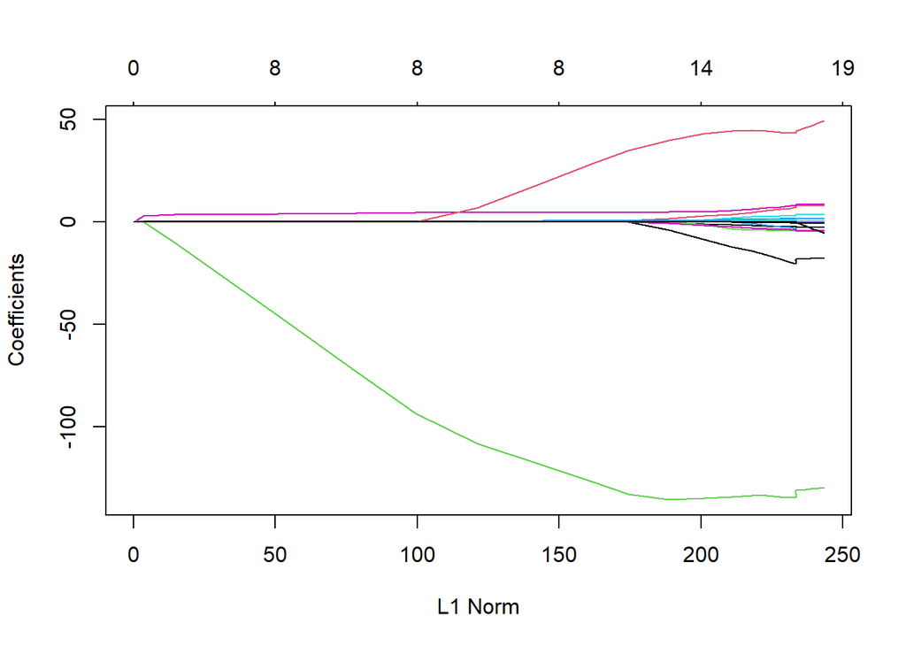

```r
lasso.mod1 <- glmnet(x_train, y_train, alpha = 1, lambda = grid)
plot(lasso.mod1)
```

We can see from the coefficient plot that depending on the choice of tuning parameter, some of the coefficients will be **exactly equal to zero**.

### Choosing $\lambda$ with Cross-Validation

Now we perform cross validation to find the best value of $\lambda$:

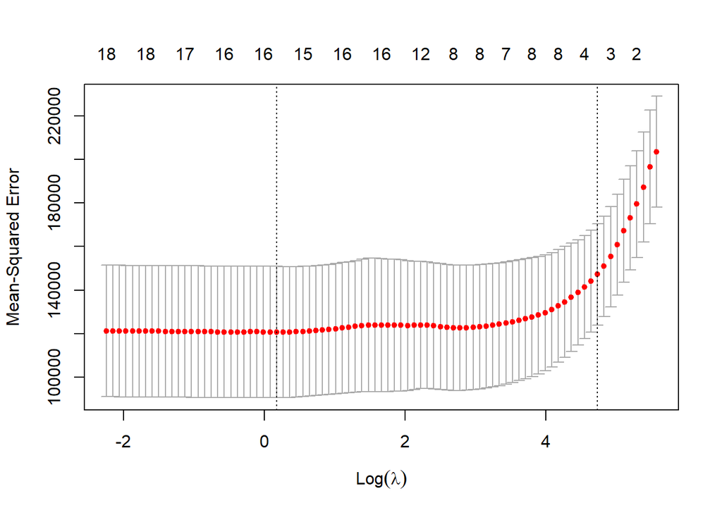

```r
set.seed(12345)
mod.lasso.cv <- cv.glmnet(x_train, y_train, type.measure = "mse", nfolds = 5)
plot(mod.lasso.cv)
```

```r
# Save Optimal Lambdas
lambda_min.lasso <- mod.lasso.cv$lambda.min
print(lambda_min.lasso)
```

```
[1] 1.189541
```

```r
coeff_min <- coef(mod.lasso.cv, s = "lambda.min")[,1]

lambda_1se.lasso <- mod.lasso.cv$lambda.1se
print(lambda_1se.lasso)
```

```
[1] 113.5474
```

```r
coeff_1se <- coef(mod.lasso.cv, s = "lambda.1se")[,1]
```

```r
data.frame(cbind(coeff_min, coeff_1se)) %>%
  kbl() %>%
  kable_styling(bootstrap_options = c("striped", "hover", "condensed"))
```

Table 9: LASSO Coefficients - Optimal Lambda

|  | coeff_min | coeff_1se |
| --- | --- | --- |
| (Intercept) | 242.3167138 | 293.7115872 |
| AtBat | -2.3746030 | 0.0000000 |
| Hits | 7.0088455 | 0.0000000 |
| HmRun | -4.2660149 | 0.0000000 |
| Runs | -3.0257019 | 0.0000000 |
| RBI | 3.1703769 | 0.0000000 |
| Walks | 7.9740935 | 2.5880568 |
| Years | -20.3546933 | 0.0000000 |
| CAtBat | -0.0017199 | 0.0000000 |
| CHits | 0.0000000 | 0.0000000 |
| CHmRun | 1.5844970 | 0.0000000 |
| CRuns | 1.0091501 | 0.2339336 |
| CRBI | 0.0000000 | 0.2171932 |
| CWalks | -0.5131176 | 0.0000000 |
| LeagueN | 43.1992322 | 0.0000000 |
| DivisionW | -134.4769998 | 0.0000000 |
| PutOuts | 0.3003368 | 0.0000000 |
| Assists | 0.3766270 | 0.0000000 |
| Errors | -3.8907645 | 0.0000000 |
| NewLeagueN | 0.0000000 | 0.0000000 |

```r
lasso.mod2 <- glmnet(x_train, y_train, alpha = 0, lambda = lambda_min.lasso)
# Test Performance (MSE)
predict_lasso <- predict(lasso.mod2, s = 4, newx = x_test)
lasso_MSE <- eval_results(y_test, predict_ridge, test_hitters)
```

| MSE | RMSE |
| --- | --- |
| 124994.8 | 353.5461 |

## $k$-fold CV Model Comparison

Just a fancy way of combining regularization with cross-validation to compare model performance.

### Lasso CV

```r
set.seed(12345)
n = nrow(hitters)
K = 10 # # folds
foldid = rep(1:K, each=ceiling(n/K))[sample(1:n)]

OOS.lasso.min=data.frame(MSE=rep(NA,K), RMSE=rep(NA, K))

for(k in 1:K){

  train = which(foldid!=k)

  # train.data conversion
  k.train <- hitters[train,]
  x_train <- model.matrix(Salary~., data = k.train)[,-1]
  y_train <- k.train$Salary

  # test.data conversion
  k.test <- hitters[-train,]
  x_test <- model.matrix(Salary~., data = k.test)[,-1]
  y_test <- k.test$Salary

  #Choosing Tuning Parameter
  mod.lasso.cv <- cv.glmnet(x_train, y_train, type.measure = "mse", nfolds = 5)
  lambda_min <- mod.lasso.cv$lambda.min
  lambda_1se <- mod.lasso.cv$lambda.1se

  #fit regression on train
  mod.lasso <- glmnet(x_train, y_train, alpha = 1, lambda = lambda_min)

  #predict on test
  predictions_test <- predict(mod.lasso, s = lambda_min, newx = x_test)

  #MSE
  OOS.lasso.min$MSE[k] <- eval_results(y_test, predictions_test, k.test)[,1]
  OOS.lasso.min$RMSE[k] <- eval_results(y_test, predictions_test, k.test)[,2]

    # print progress
  cat(k, "  ")

}
```

```
1   2   3   4   5   6   7   8   9   10
```

```r
mean(OOS.lasso.min$RMSE)
```

```
[1] 329.0406
```

```r
set.seed(12345)
n = nrow(hitters)
K = 10 # # folds
foldid = rep(1:K, each=ceiling(n/K))[sample(1:n)]

OOS.lasso.1se=data.frame(MSE=rep(NA,K), RMSE=rep(NA, K))


for(k in 1:K){

  train = which(foldid!=k)

  # train.data conversion
  k.train <- hitters[train,]
  x_train <- model.matrix(Salary~., data = k.train)[,-1]
  y_train <- k.train$Salary

  # test.data conversion
  k.test <- hitters[-train,]
  x_test <- model.matrix(Salary~., data = k.test)[,-1]
  y_test <- k.test$Salary

  #Choosing Tuning Parameter
  mod.lasso.cv <- cv.glmnet(x_train, y_train, type.measure = "mse", nfolds = 5)
  lambda_min <- mod.lasso.cv$lambda.min
  lambda_1se <- mod.lasso.cv$lambda.1se

  #fit regression on train
  mod.lasso <- glmnet(x_train, y_train, alpha = 1, lambda = lambda_1se)

  #predict on test
  predictions_test <- predict(mod.lasso, s = lambda_1se, newx = x_test)

  #MSE
  OOS.lasso.1se$MSE[k] <- eval_results(y_test, predictions_test, k.test)[,1]
  OOS.lasso.1se$RMSE[k] <- eval_results(y_test, predictions_test, k.test)[,2]

    # print progress
  cat(k, "  ")

}
```

```
1   2   3   4   5   6   7   8   9   10
```

```r
mean(OOS.lasso.1se$RMSE)
```

```
[1] 358.0974
```

### Ridge CV

```r
set.seed(12345)
n = nrow(hitters)
K = 10 # # folds
foldid = rep(1:K, each=ceiling(n/K))[sample(1:n)]

OOS.ridge.min=data.frame(MSE=rep(NA,K), RMSE=rep(NA, K))


for(k in 1:K){

  train = which(foldid!=k)

  # train.data conversion
  k.train <- hitters[train,]
  x_train <- model.matrix(Salary~., data = k.train)[,-1]
  y_train <- k.train$Salary

  # test.data conversion
  k.test <- hitters[-train,]
  x_test <- model.matrix(Salary~., data = k.test)[,-1]
  y_test <- k.test$Salary

  #Choosing Tuning Parameter
  mod.ridge.cv <- cv.glmnet(x_train, y_train, alpha=0, type.measure = "mse", nfolds = 5)
  lambda_min <- mod.ridge.cv$lambda.min
  lambda_1se <- mod.ridge.cv$lambda.1se

  #fit regression on train
  mod.ridge <- glmnet(x_train, y_train, alpha = 0, lambda = lambda_min)

  #predict on test
  predictions_test <- predict(mod.ridge, s = lambda_min, newx = x_test)

  #MSE
  OOS.ridge.min$MSE[k] <- eval_results(y_test, predictions_test, k.test)[,1]
  OOS.ridge.min$RMSE[k] <- eval_results(y_test, predictions_test, k.test)[,2]

    # print progress
  cat(k, "  ")

}
```

```
1   2   3   4   5   6   7   8   9   10
```

```r
mean(OOS.ridge.min$RMSE)
```

```
[1] 331.3975
```

```r
set.seed(12345)
n = nrow(hitters)
K = 10 # # folds
foldid = rep(1:K, each=ceiling(n/K))[sample(1:n)]

OOS.ridge.1se=data.frame(MSE=rep(NA,K), RMSE=rep(NA, K))


for(k in 1:K){

  train = which(foldid!=k)

  # train.data conversion
  k.train <- hitters[train,]
  x_train <- model.matrix(Salary~., data = k.train)[,-1]
  y_train <- k.train$Salary

  # test.data conversion
  k.test <- hitters[-train,]
  x_test <- model.matrix(Salary~., data = k.test)[,-1]
  y_test <- k.test$Salary

  #Choosing Tuning Parameter
  mod.ridge.cv <- cv.glmnet(x_train, y_train, alpha=0, type.measure = "mse", nfolds = 5)
  lambda_min <- mod.ridge.cv$lambda.min
  lambda_1se <- mod.ridge.cv$lambda.1se

  #fit regression on train
  mod.ridge <- glmnet(x_train, y_train, alpha = 0, lambda = lambda_1se)

  #predict on test
  predictions_test <- predict(mod.ridge, s = lambda_1se, newx = x_test)

  #MSE
  OOS.ridge.1se$MSE[k] <- eval_results(y_test, predictions_test, k.test)[,1]
  OOS.ridge.1se$RMSE[k] <- eval_results(y_test, predictions_test, k.test)[,2]

    # print progress
  cat(k, "  ")

}
```

```
1   2   3   4   5   6   7   8   9   10
```

```r
mean(OOS.ridge.1se$RMSE)
```

```
[1] 359.3406
```

Finally, we build the plot that compares all the four models:

```r
OOS.lasso.min <- OOS.lasso.min %>% mutate(Model="Lasso Min")
OOS.lasso.1se <- OOS.lasso.1se %>% mutate(Model="Lasso 1SE")

OOS.ridge.min <- OOS.ridge.min %>% mutate(Model="Ridge Min")
OOS.ridge.1se <- OOS.ridge.1se %>% mutate(Model="Ridge 1SE")

### MERGE
OOS <- rbind(OOS.lasso.min, OOS.lasso.1se, OOS.ridge.min, OOS.ridge.1se)
```

#### Model Comparison Plot

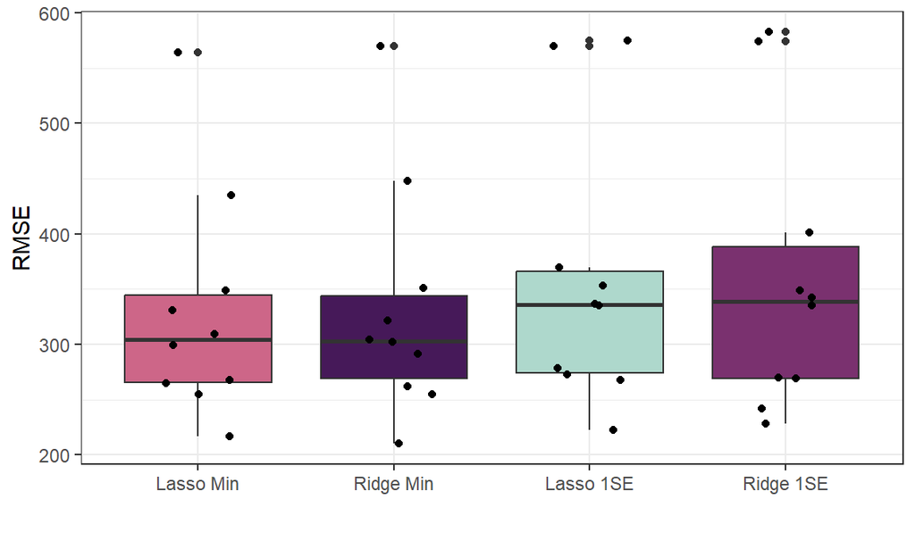

Figure 2: Model Comparison: k-fold Out-of-Sample RMSE

```r
OOS %>%
  #filter(!Model=="OLS") %>%
  ggplot( aes(x=reorder(Model,RMSE), y=RMSE, fill=Model)) +
  geom_boxplot() +
  geom_jitter(shape=16, position=position_jitter(0.2)) +
  theme_bw() + theme(legend.position="none") +
  xlab("") +
  scale_y_continuous(labels = scales::comma) +
  scale_fill_manual(values = mycolors)
```